# Data 624 Homework 6: ARIMA

## Question 8.3

For the following series, find an appropriate Box-Cox transformation and order of differencing in order to obtain stationary data.

1. `usnetelec`

The plot for `usnetelec` shows an upward trend, which must be addressed to obtain stationary data.

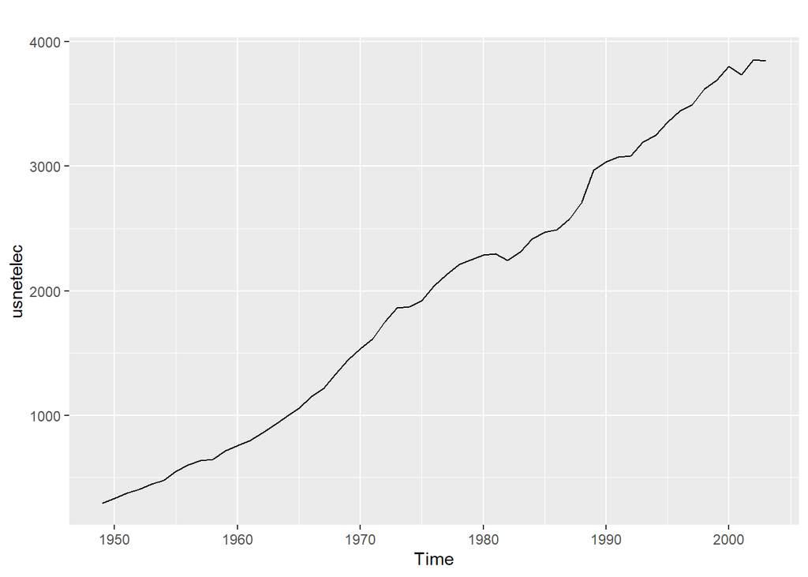

```r
autoplot(usnetelec)
```

The ACF and PACF plots tell us that most of the autocorrelation comes from the previous time series value. We can difference at lag = 1 to correct this.

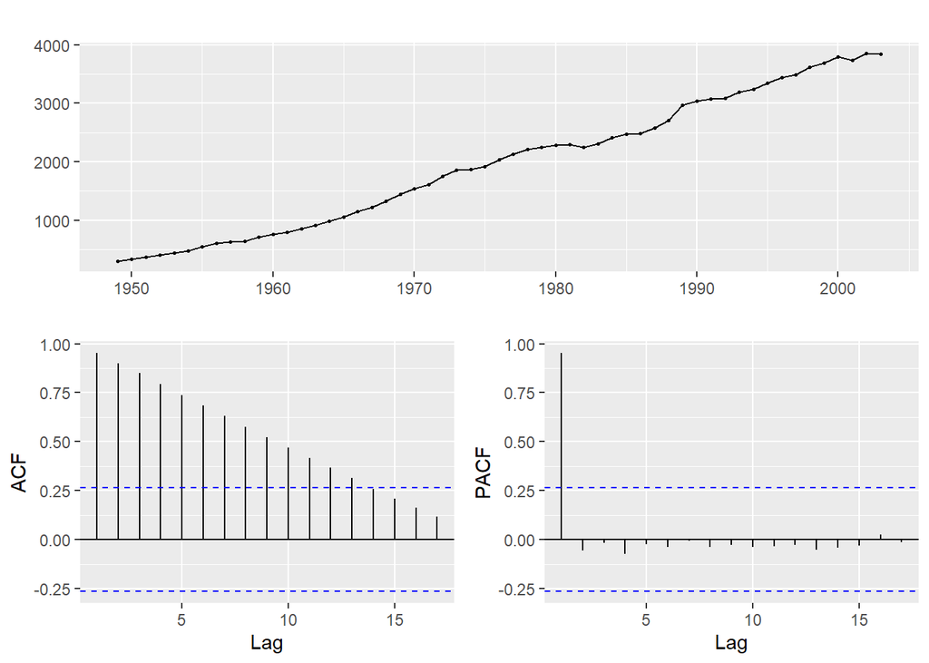

```r
ggtsdisplay(usnetelec)
```

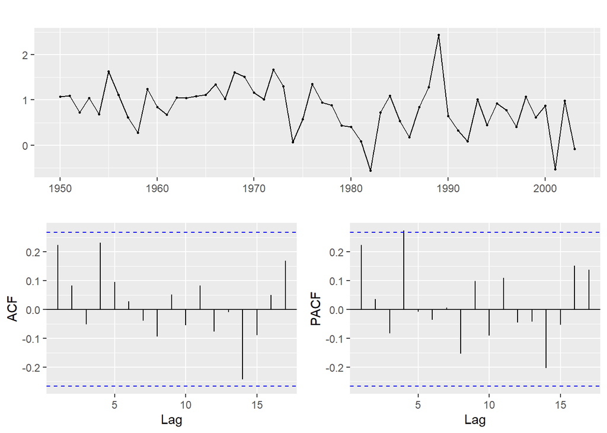

```r
ggtsdisplay(usnetelec %>% sqrt() %>% diff(1))
```

```r
Box.test(usnetelec %>% sqrt() %>% diff(1),lag=10, fitdf=0, type="Lj")
```

```
##
##  Box-Ljung test
##
## data:  usnetelec %>% sqrt() %>% diff(1)
## X-squared = 8.2901, df = 10, p-value = 0.6005
```

```r
usnetelec %>% sqrt() %>% diff(1) %>% ur.kpss() %>% summary()
```

```
##
## #######################
## # KPSS Unit Root Test #
## #######################
##
## Test is of type: mu with 3 lags.
##
## Value of test-statistic is: 0.4656
##
## Critical value for a significance level of:
##                 10pct  5pct 2.5pct  1pct
## critical values 0.347 0.463  0.574 0.739
```

2. `usgdp`

The plot for `usgdp` shows an upward trend, which must be addressed to obtain stationary data. There does not seem to be significant seasonality.

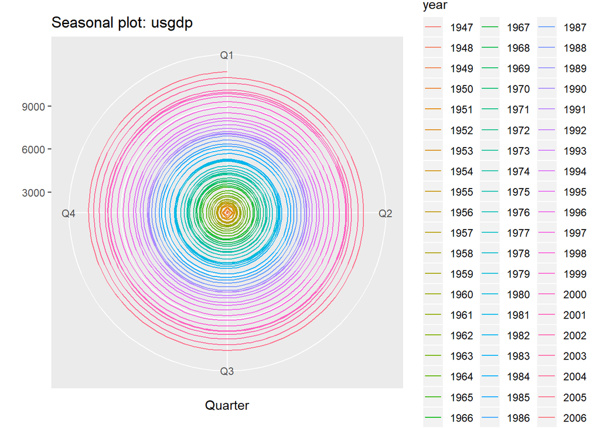

```r
ggseasonplot(usgdp, polar = TRUE)
```

The ACF and PACF plots tell us that most of the autocorrelation comes from the previous time series value. We can difference at lag = 1 to correct this.

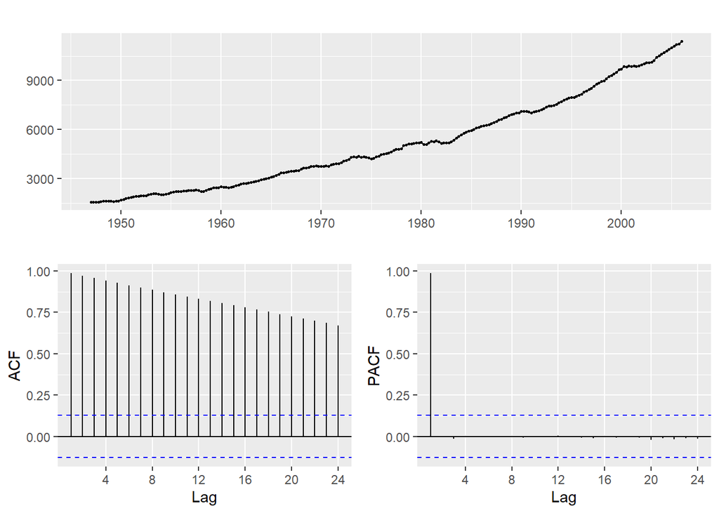

```r
ggtsdisplay(usgdp)
```

We see that taking a difference at lag 1 and performing a BoxCox transform does not address all the autocorrelation, since:

- Some of the autocorrelations fall outside the interval (lag = 1, lag = 12)
- The portmanteau test produces a significant p-value
- However, the unit root test has a test statistic within the range for stationary data

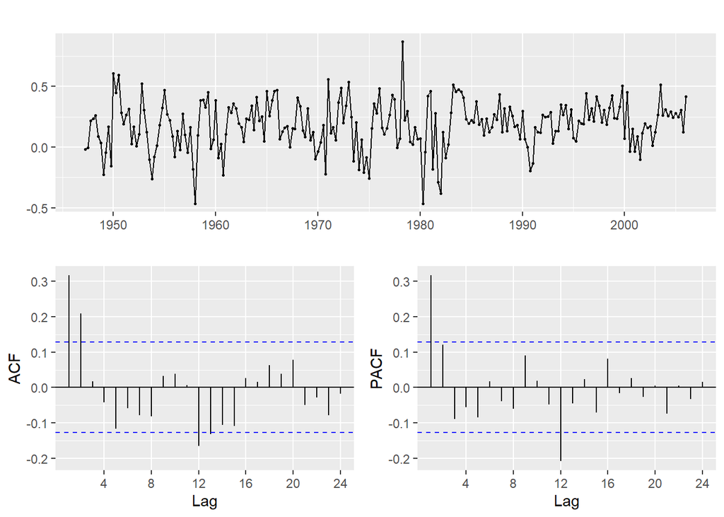

```r
ggtsdisplay(usgdp  %>% BoxCox(BoxCox.lambda(usgdp)) %>% diff(1))
```

```r
Box.test(usgdp %>% BoxCox(BoxCox.lambda(usgdp)) %>% diff(1),lag=24, fitdf=0, type="Lj")
```

```
##
##  Box-Ljung test
##
## data:  usgdp %>% BoxCox(BoxCox.lambda(usgdp)) %>% diff(1)
## X-squared = 65.525, df = 24, p-value = 1.019e-05
```

```r
usgdp %>% BoxCox(BoxCox.lambda(usgdp)) %>% diff(1) %>% ur.kpss() %>% summary()
```

```
##
## #######################
## # KPSS Unit Root Test #
## #######################
##
## Test is of type: mu with 4 lags.
##
## Value of test-statistic is: 0.2013
##
## Critical value for a significance level of:
##                 10pct  5pct 2.5pct  1pct
## critical values 0.347 0.463  0.574 0.739
```

3. `mcopper`

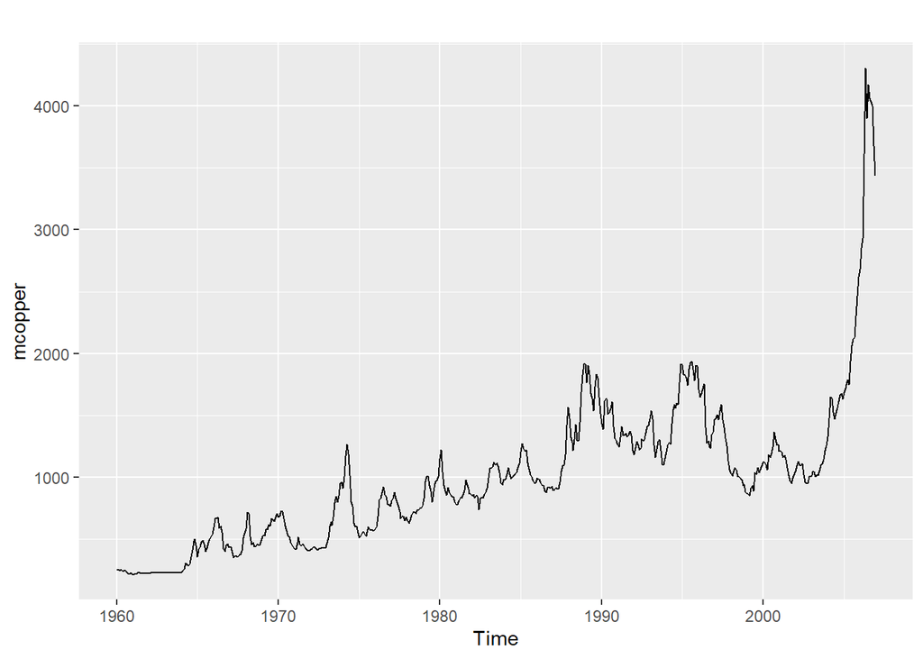

```r
autoplot(mcopper)
```

The ACF and PACF plots tell us that most of the autocorrelation comes from the previous time series value. We can difference at lag = 1 to attempt to correct this.

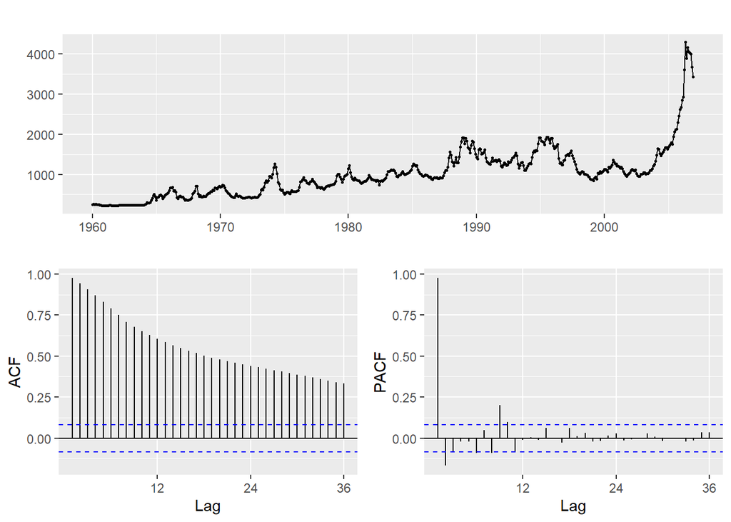

```r
ggtsdisplay(mcopper)
```

We see that taking a difference at lag 1 and performing a log transform does make the time series stationary (but still autocorrelated), since:

- Some of the autocorrelations fall outside the interval (lag = 1 particularly)
- The portmanteau test produces a significant p-value
- However, the unit root test has a test statistic within the range for stationary data

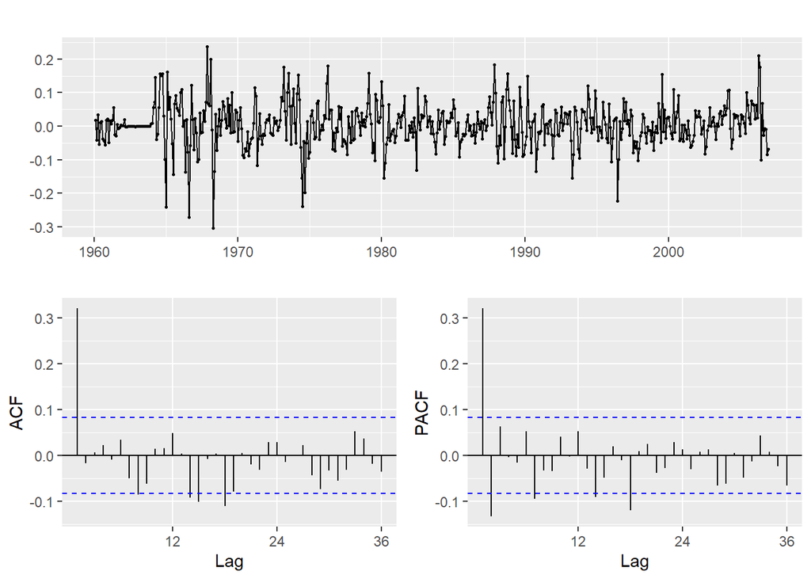

```r
ggtsdisplay(mcopper  %>% log() %>% diff(1))
```

```r
Box.test(mcopper %>% log() %>% diff(1),lag=24, fitdf=0, type="Lj")
```

```
##
##  Box-Ljung test
##
## data:  mcopper %>% log() %>% diff(1)
## X-squared = 92.239, df = 24, p-value = 6.121e-10
```

```r
mcopper %>% log() %>% diff(1) %>% ur.kpss() %>% summary()
```

```
##
## #######################
## # KPSS Unit Root Test #
## #######################
##
## Test is of type: mu with 6 lags.
##
## Value of test-statistic is: 0.0425
##
## Critical value for a significance level of:
##                 10pct  5pct 2.5pct  1pct
## critical values 0.347 0.463  0.574 0.739
```

4. `enplanements`

The time series plot for `enplanements` shows strong seasonality, an upwards trend, and changing variability.

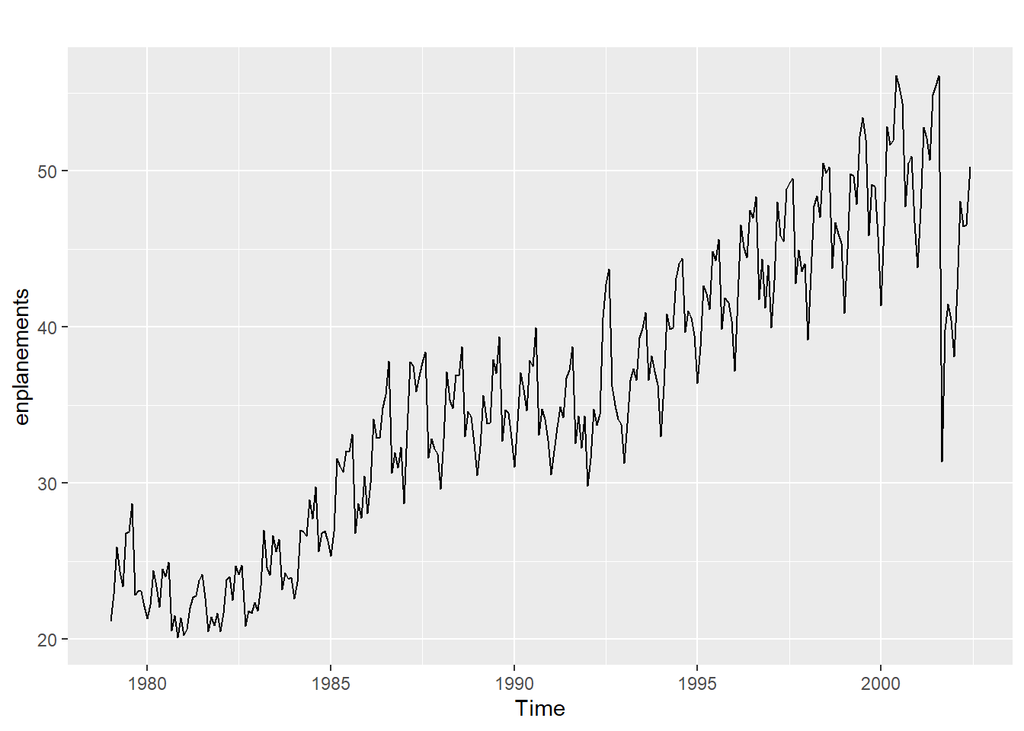

```r
autoplot(enplanements)
```

The ACF and PACF plots show that there is autocorrection with previous values and on a seasonal basis. We can address all of the issues with this time series by taking a BoxCox transform, and applying seasonal differencing.

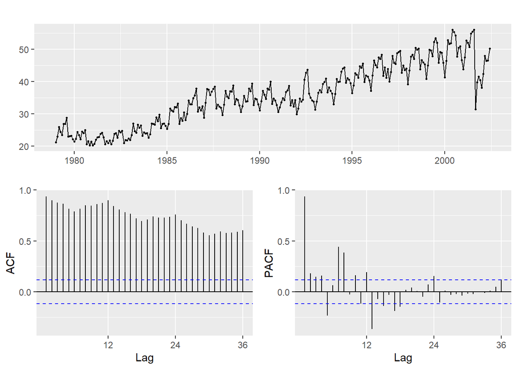

```r
ggtsdisplay(enplanements)
```

We see that performing a BoxCox transform, seasonal differencing, and taking a difference at lag 1 does make the time series stationary (but still autocorrelated), since:

- Some of the autocorrelations fall outside the interval (lag = 1 particularly)
- The portmanteau test produces a significant p-value
- However, the unit root test has a test statistic within the range for stationary data

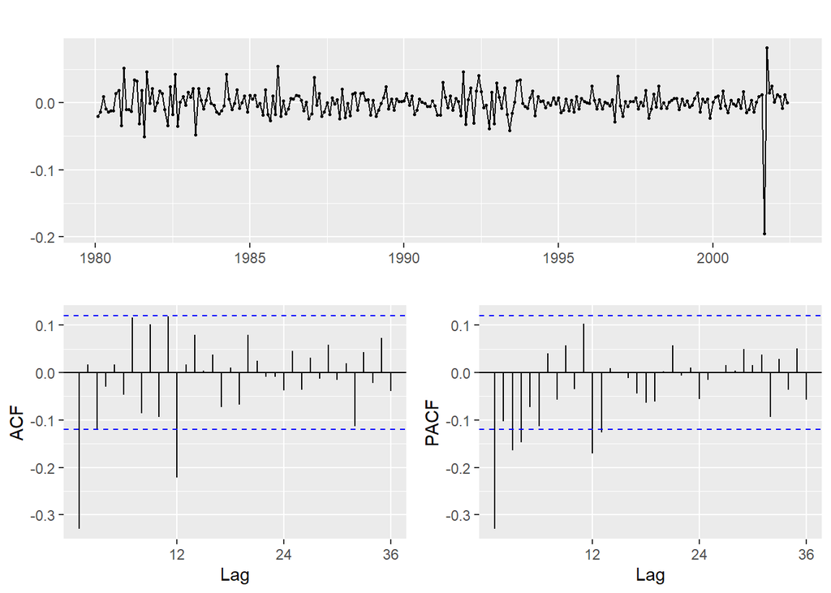

```r
ggtsdisplay(enplanements %>% BoxCox(BoxCox.lambda(enplanements))  %>% diff(12) %>% diff(1))
```

```r
Box.test(enplanements %>% BoxCox(BoxCox.lambda(enplanements))  %>% diff(12) %>% diff(1),lag=24, fitdf=0, type="Lj")
```

```
##
##  Box-Ljung test
##
## data:  enplanements %>% BoxCox(BoxCox.lambda(enplanements)) %>% diff(12) %>%     diff(1)
## X-squared = 71.176, df = 24, p-value = 1.449e-06
```

```r
enplanements %>% BoxCox(BoxCox.lambda(enplanements))  %>% diff(12) %>% diff(1) %>% ur.kpss() %>% summary()
```

```
##
## #######################
## # KPSS Unit Root Test #
## #######################
##
## Test is of type: mu with 5 lags.
##
## Value of test-statistic is: 0.0424
##
## Critical value for a significance level of:
##                 10pct  5pct 2.5pct  1pct
## critical values 0.347 0.463  0.574 0.739
```

5. `visitors`

The time series plot for `visitors` shows strong seasonality, an upwards trend, and changing variability.

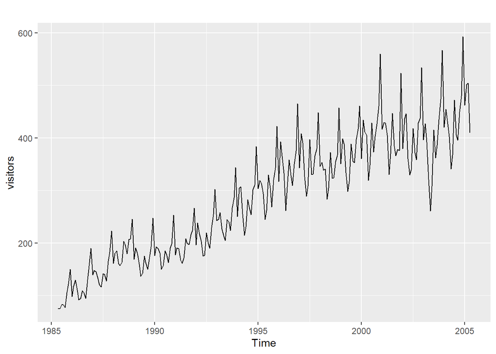

```r
autoplot(visitors)
```

The ACF and PACF plots show that there is autocorrection with previous values and on a seasonal basis. We can address all of the issues with this time series by taking a BoxCox transform, and applying seasonal differencing.

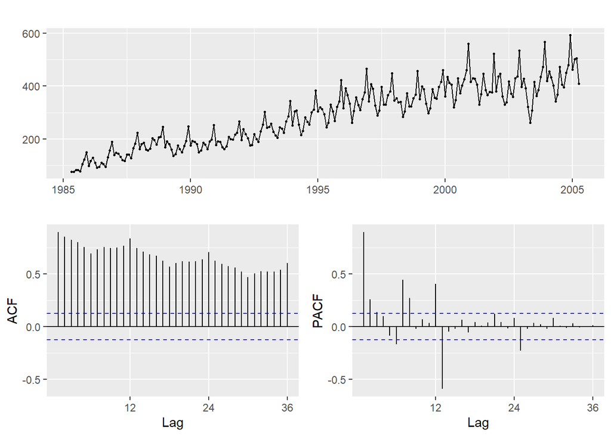

```r
ggtsdisplay(visitors)
```

We see that performing a BoxCox transform, seasonal differencing, and taking a difference at lags 12 and 1 does make the time series stationary (but still autocorrelated), since:

- Some of the autocorrelations fall outside the interval (lag = 12 particularly)
- The portmanteau test produces a significant p-value
- However, the unit root test has a test statistic within the range for stationary data

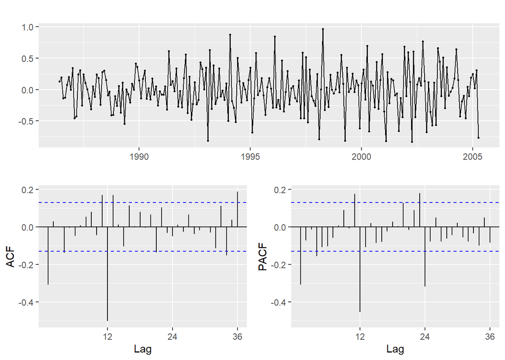

```r
ggtsdisplay(visitors %>% BoxCox(BoxCox.lambda(visitors)) %>% diff(12) %>% diff(1))
```

```r
Box.test(visitors %>% BoxCox(BoxCox.lambda(visitors))  %>% diff(12) %>% diff(1),lag=24, fitdf=0, type="Lj")
```

```
##
##  Box-Ljung test
##
## data:  visitors %>% BoxCox(BoxCox.lambda(visitors)) %>% diff(12) %>%     diff(1)
## X-squared = 121.61, df = 24, p-value = 4.996e-15
```

```r
visitors %>% BoxCox(BoxCox.lambda(visitors))  %>% diff(12) %>% diff(1) %>% ur.kpss() %>% summary()
```

```
##
## #######################
## # KPSS Unit Root Test #
## #######################
##
## Test is of type: mu with 4 lags.
##
## Value of test-statistic is: 0.0158
##
## Critical value for a significance level of:
##                 10pct  5pct 2.5pct  1pct
## critical values 0.347 0.463  0.574 0.739
```

## Question 8.5

For your retail data (from Exercise 3 in Section 2.10), find the appropriate order of differencing (after transformation if necessary) to obtain stationary data.

Taking a look at this plot, a BoxCox transform will be needed because of the changing variance. Seasonal differencing may also be needed, because this data is highly seasonal. The upwards trend will also require differencing to address.

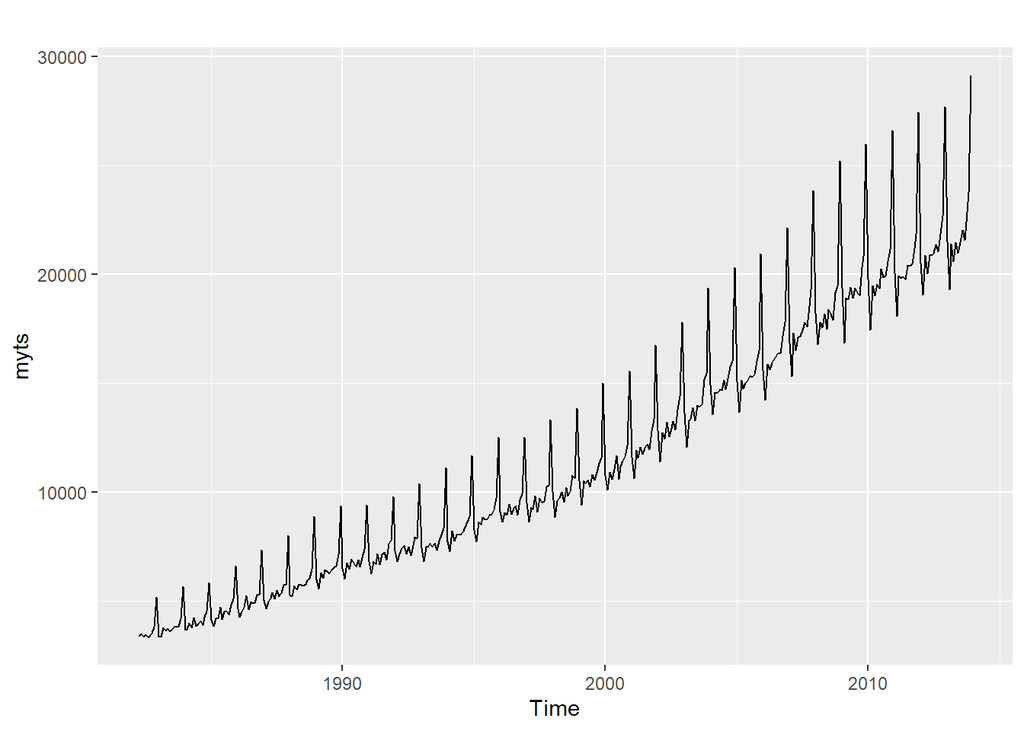

```r
temp = tempfile(fileext = ".xlsx")
dataURL <- "https://otexts.com/fpp2/extrafiles/retail.xlsx"
download.file(dataURL, destfile=temp, mode='wb')
retaildata <- readxl::read_excel(temp, skip=1)
myts <- ts(retaildata[,"A3349396W"], frequency=12, start=c(1982,4))
autoplot(myts)
```

The season plot shows annual seasonality.

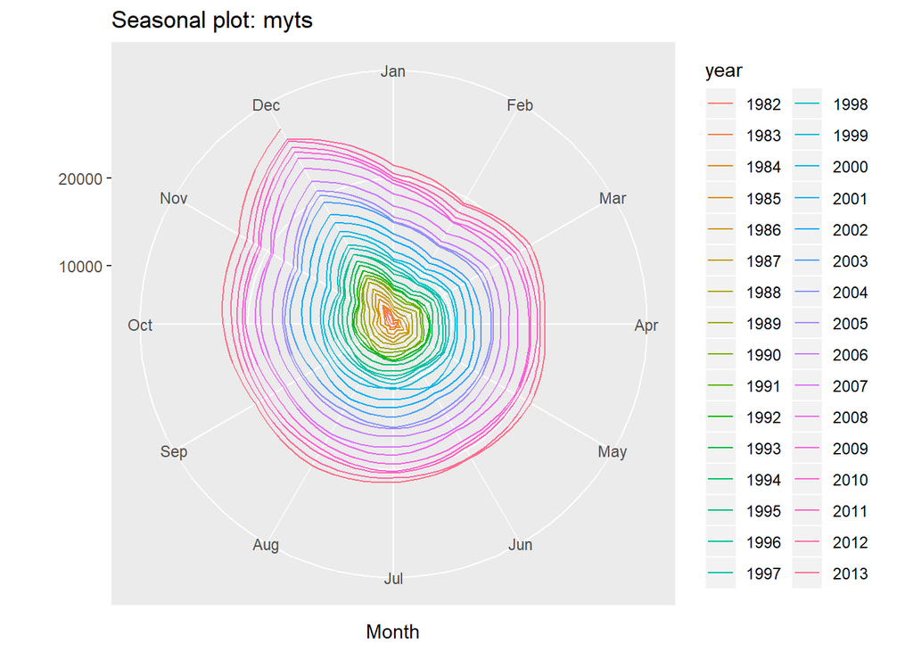

```r
ggseasonplot(myts, polar = TRUE)
```

```r
myts %>% BoxCox(BoxCox.lambda(myts)) %>% diff(12) %>% diff(1) %>% ur.kpss() %>% summary()
```

```
##
## #######################
## # KPSS Unit Root Test #
## #######################
##
## Test is of type: mu with 5 lags.
##
## Value of test-statistic is: 0.0153
##
## Critical value for a significance level of:
##                 10pct  5pct 2.5pct  1pct
## critical values 0.347 0.463  0.574 0.739
```

## Question 8.6

Use R to simulate and plot some data from simple ARIMA models.

1. Use the following R code to generate data from an AR(1) model with ϕ1 = 0.6 and σ^2=1. The process starts with y1=0.

```r
y <- ts(numeric(100))
e <- rnorm(100)
```

2. Produce a time plot for the series. How does the plot change as you change ϕ1?

As ϕ1 increases, the time plot becomes smoother. Lower values of ϕ1 result in more variability in the time series.

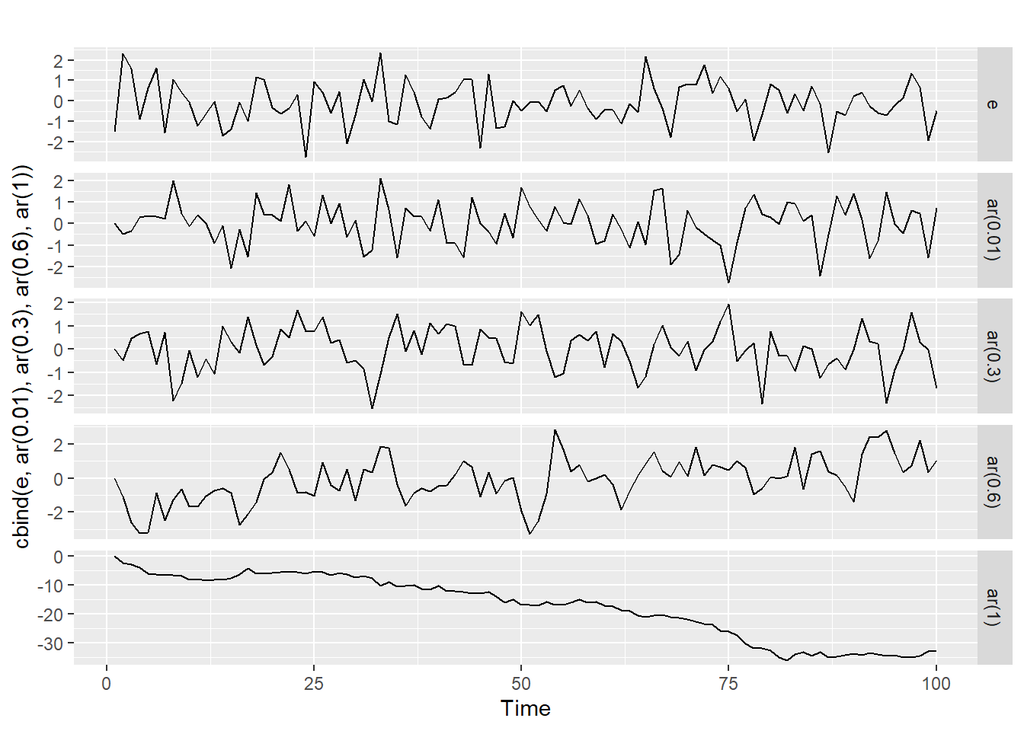

```r
ar <- function(theta){
  y <- ts(numeric(100))
  e <- rnorm(100, sd=1)
  for(i in 2:100){
    y[i] <- theta*y[i-1] + e[i]}
  return(y)
}

autoplot(cbind(e, ar(.01), ar(.3), ar(.6), ar(1)), facet = TRUE)
```

3. Write your own code to generate data from an MA(1) model with θ1=0.6 and σ2=1.

```r
ma <- function(theta){
  y <- ts(numeric(100))
  e <- rnorm(100, sd=1)
  for(i in 2:100){
    y[i] <- theta*e[i-1] + e[i]}
  return(y)
}
ma(0.6)
```

[output not shown]

4. Produce a time plot for the series. How does the plot change as you change θ1?

As θ1 changes, the pattern of the time series remains consistant. The scale of the time series values increases with θ1.

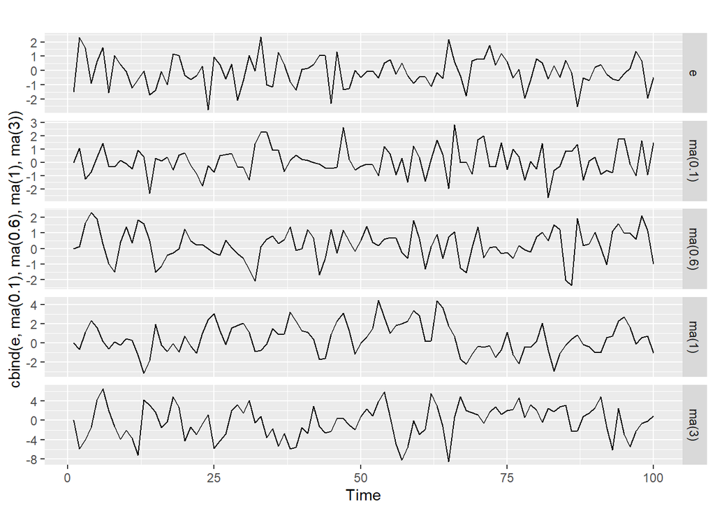

```r
autoplot(cbind(e, ma(.1), ma(.6), ma(1), ma(3)), facet = TRUE)
```

5. Generate data from an ARMA(1,1) model with ϕ1=0.6, θ1=0.6 and σ2=1.

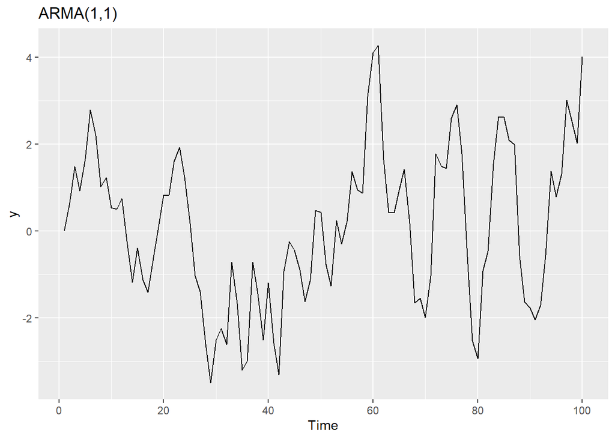

```r
y <- ts(numeric(100))
e <- rnorm(100, sd=1)
for(i in 2:100){
  y[i] <- 0.6*y[i-1] + 0.6*e[i-1] + e[i]
}

autoplot(y) +
  ggtitle('ARMA(1,1)')
```

6. Generate data from an AR(2) model with ϕ1=−0.8, ϕ2=0.3 and σ2=1. (Note that these parameters will give a non-stationary series.)

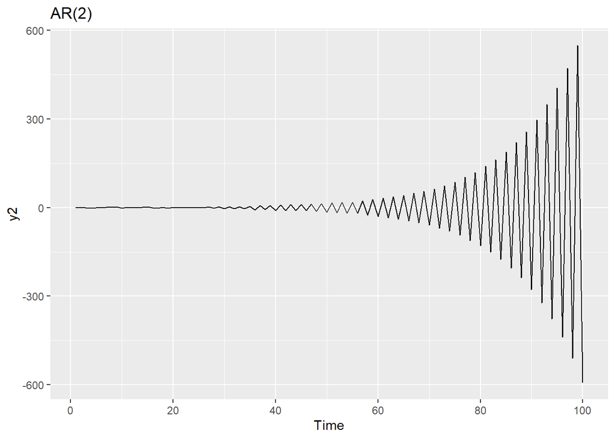

```r
y2 <- ts(numeric(100))
e <- rnorm(100, sd=1)
for(i in 3:100){
  y2[i] <- (-0.8)*y2[i-1] + 0.3*y2[i-2] + e[i]
}

autoplot(y2) +
  ggtitle('AR(2)')
```

7. Graph the latter two series and compare them.

The AR(2) series ends up oscillating around a mean of 0 with increasing variance over time. ARMA(1,1) is the better model, although it also has high autocorrelation.

The reason AR(2) is such a poor model is because it does not follow the following constraint: ϕ2 − ϕ1 < 1

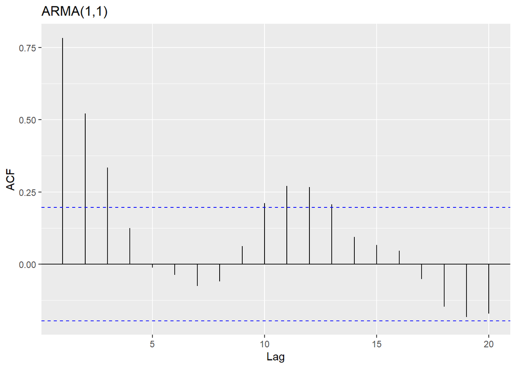

```r
ggAcf(y) + ggtitle('ARMA(1,1)')
```

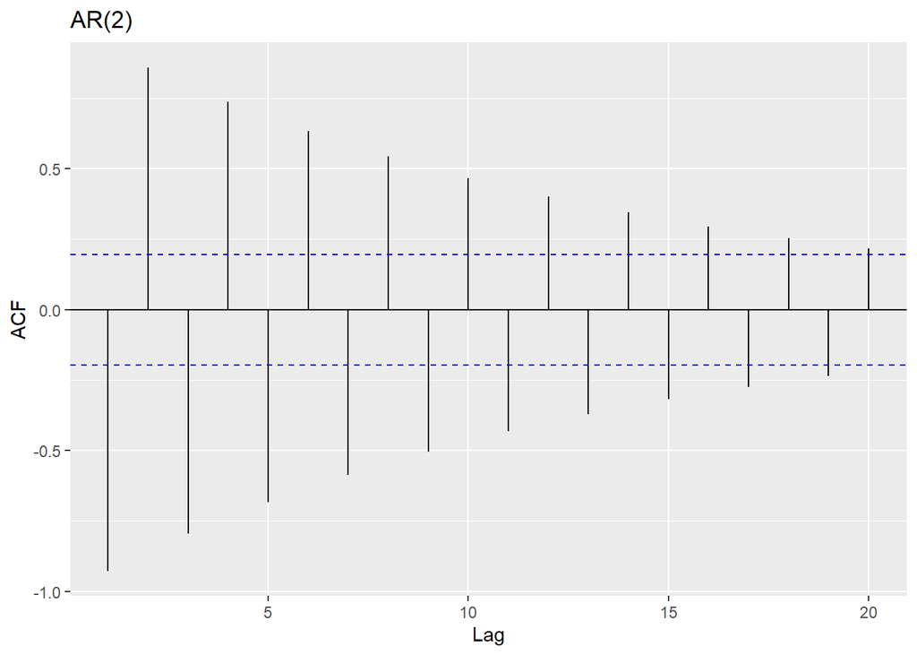

```r
ggAcf(y2) + ggtitle('AR(2)')
```